# Week 12 - Milestone Two week

# 1. Lesson: no lesson this week. Milestone Two is due!

# 2. Weekly graph question

Suppose you plot the number visitors to a museum over the seven days of a week; then again the following week. Can you suggest the advantages and disadvantages of the following two ways of presenting the data?

```python
import numpy as np
import seaborn as sns
import pandas as pd
import matplotlib.pyplot as plt
```

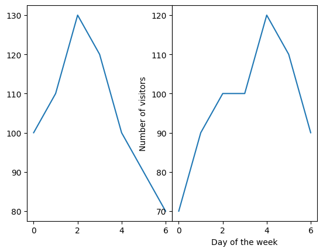

```python
np.random.seed(0)
time_series_0 = np.array([100, 110, 130, 120, 100, 90, 80])
time_series_1 = np.array([70, 90, 100, 100, 120, 110, 90])
fig, axs = plt.subplots(1, 2)
axs[0].plot(time_series_0)
axs[1].plot(time_series_1)
plt.subplots_adjust(wspace = 0)
plt.xlabel("Day of the week")
plt.ylabel("Number of visitors")
```

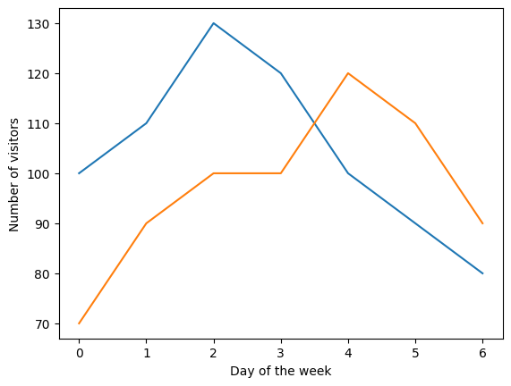

```python
plt.plot(time_series_0)
plt.plot(time_series_1)
plt.xlabel("Day of the week")
plt.ylabel("Number of visitors")
```

The top plot has some disadvantages. First, the scale of the y axis on the side by side plots are different, making it difficult to compare the data. Additionally, since the lines do not overlap like in the second plot, it is difficult to compare each day between the two weeks. Next, you cannot tell which plot corresponds to which week. Better labeling should be added to indicate that. Finally, the Day of the week should be changed to text to make it more clear.

The second plot does a better job at displaying the data in a way that can be compared. One improvement that is still needed is that a legend should be added. In the current plot, you cannot tell which line correpsonds to which week. Additionally, the Day of the week should be changed to text such as 0 -> Monday which would make it more clear.

# 3. Working on your datasets

This week, you can work on Milestone Two rather than having a particular exercise about working on your datasets

# 4. Storytelling With Data plot

Reproduce any graph of your choice in p. 187-205 of the Storytelling With Data book as best you can. (Chapter Eight). You do not have to get the exact data values right, just the overall look and feel.

```python
import matplotlib.pyplot as plt
import matplotlib.ticker as mtick
```

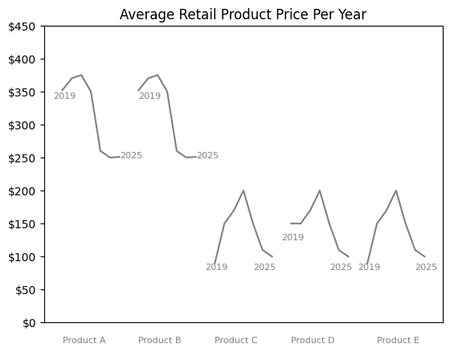

```python
# Chapter 8 fig 4
x1 = [0,1,2,3,4,5,6]
y1 = [352, 370, 375, 350, 260, 250, 251]

x2 = [8,9,10,11,12,13,14]
y2 = [352, 370, 375, 350, 260, 250, 251]

x3 = [16,17,18,19,20,21,22]
y3 = [90, 150, 170, 200, 150, 110, 100]

x4 = [24,25,26,27,28,29,30]
y4 = [150, 150, 170, 200, 150, 110, 100]

x5 = [32,33,34,35,36,37,38]
y5 = [90, 150, 170, 200, 150, 110, 100]

fig, ax = plt.subplots()

ax.plot(x1, y1, color='gray')
ax.plot(x2, y2, color='gray')
ax.plot(x3, y3, color='gray')
ax.plot(x4, y4, color='gray')
ax.plot(x5, y5, color='gray')

plt.ylim(0, 450)
plt.xticks([])

plt.text(-1, 340, '2019', fontsize=8, color='gray')
plt.text(6, 250, '2025', fontsize=8, color='gray')

plt.text(8, 340, '2019', fontsize=8, color='gray')
plt.text(14, 250, '2025', fontsize=8, color='gray')

plt.text(15, 80, '2019', fontsize=8, color='gray')
plt.text(20, 80, '2025', fontsize=8, color='gray')

plt.text(23, 125, '2019', fontsize=8, color='gray')
plt.text(28, 80, '2025', fontsize=8, color='gray')

plt.text(31, 80, '2019', fontsize=8, color='gray')
plt.text(37, 80, '2025', fontsize=8, color='gray')

plt.text(0, -30, 'Product A', fontsize=8, color='gray')
plt.text(8, -30, 'Product B', fontsize=8, color='gray')
plt.text(16, -30, 'Product C', fontsize=8, color='gray')
plt.text(24, -30, 'Product D', fontsize=8, color='gray')
plt.text(33, -30, 'Product E', fontsize=8, color='gray')


fmt = '${x:,.0f}'
tick = mtick.StrMethodFormatter(fmt)
ax.yaxis.set_major_formatter(tick)

plt.title("Average Retail Product Price Per Year")
```